# Ejemplo: Medición Confiable con Indicadores Binarios

Héctor Nájera

2025-04-20

## 1. Simulación de Indicadores Binarios con Alta Confiabilidad

Lo primero que haremos es mostrar lo que ocurre, desde el punto de vista de la teoría estadística, cuando tenemos una medición de pobreza con bajo error aleatorio. Para ello simularemos un índice de variable binarias con bajo error de medición.

Simulamos una variable latente (pobreza) y seis indicadores binarios con una relación muy fuerte con esta, i.e., la mayor parte de la variabilidad de los indicadores se explica por cambios en la variable latente.

```r
set.seed(123)
N <- 2000
eta <- rnorm(N)  # variable latente

inv_logit <- function(x) {
  exp(x) / (1 + exp(x))
}

# Queremos varianza explicada (R²) ≈ 0.95 → alta relación pero sin saturar
# Para eso usamos una función logística con moderadas pendientes (e.g., 3.5)
beta <- rep(3.5, 6)  # log-odds scaling (relación con la latente)
intercepts <- rep(0, 6)  # punto medio = 0 (simetría)

# Probabilidades para cada ítem
logit_probs <- sapply(1:6, function(j) {
  inv_logit(beta[j] * eta + intercepts[j])
})

# Simulamos ítems binarios
items <- as.data.frame(sapply(1:6, function(j) {
  rbinom(N, size = 1, prob = logit_probs[, j])
}))

colnames(items) <- paste0("item", 1:6)
```

## 2. Modelo de Medición: CFA con Variables Categóricas

A continuación estimaremos un modelo de análisis factorial confirmatorio (AFC o CFA en inglés). Estos modelos permiten estimar la cantidad de señal atribuible a una variable latente. En el extremo, cuando la variabilidad de un ítem es totalmente atribuible a la variable de interés, lo que esperaríamos es que la proporción de la varianza explicada sea 100%. Un ejemplo de este comportamiento sería un termómetro bien calibrado o un reloj atómico.

En este bloque ajustamos un **modelo de análisis factorial confirmatorio (CFA)** con 6 indicadores binarios usando el paquete `lavaan`.

- `factor` es la **variable latente no observada** (por ejemplo: pobreza).
- `=~` se lee como: **“es medido por”**.
- `item1 + item2 + ...` son los **ítems observados** del cuestionario.
- En resumen: estamos diciendo que esos 6 ítems reflejan el mismo constructo latente.
- `modelo`: el modelo de medición que definimos antes.
- `data = items`: usamos la base de datos que contiene los ítems.
- `ordered = names(items)`: le indicamos a lavaan que todos los ítems son variables **categóricas** (por ejemplo, 0 = no, 1 = sí).
- `estimator = "WLSMV"`: es el estimador robusto recomendado para variables ordinales o binarios. Ajusta mejor los errores y los valores de ajuste cuando no hay normalidad.
- Valida si las preguntas realmente miden **un solo constructo común**.
- Permite estimar un **puntaje compuesto más confiable** que la suma simple.
- Es la base para modelos más complejos: medición por grupos, longitudinal, estructural (SEM).

```r
modelo <- '
  factor =~ item1 + item2 + item3 + item4 + item5 + item6
'

ajuste <- cfa(modelo, data = items, ordered = names(items), estimator = "WLSMV")
```

## 3. Coeficiente de Determinación $R^2$

Una vez ajustado el modelo CFA, podemos calcular el **coeficiente de determinación $R^2$** para cada ítem. Este valor indica **qué proporción de la varianza del ítem es explicada por el factor latente**.

- `inspect(ajuste, "r2")` obtiene un vector con los valores $R^2$ para cada ítem del modelo.
- Estos valores nos dicen **qué tan bien el factor latente predice cada ítem**.
  - Un $R^2$ cercano a 1 indica una relación fuerte (alta varianza explicada),
  - Un $R^2$ cercano a 0 indica una relación débil (el ítem no es bien explicado por el factor).
- Si todos los $R^2$ son altos (> 0.5), el modelo tiene buena confiabilidad, i.e., bajo error aleatorio.
- Si uno o más son bajos (< 0.3), puede ser señal de un ítem débil o con poco poder explicativo.

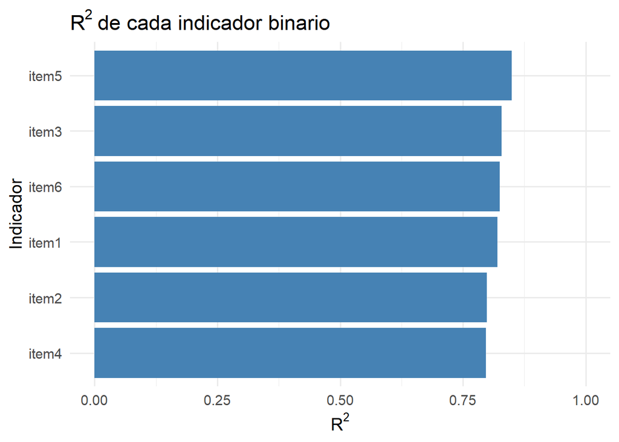

```r
r2 <- inspect(ajuste, "r2")
r2_df <- data.frame(item = names(r2), R2 = as.numeric(r2))

ggplot(r2_df, aes(x = reorder(item, R2), y = R2)) +
  geom_col(fill = "steelblue") +
  coord_flip() +
  ylim(0, 1) +
  labs(title = expression(R^2 ~ "de cada indicador binario"),
       x = "Indicador", y = expression(R^2)) +
  theme_minimal(base_size = 14)
```

## 4. Evaluación Global del Modelo

Una vez que ajustamos un modelo CFA, es importante evaluar **qué tan bien se ajusta el modelo a los datos observados**. Para ello usamos distintos **índices de ajuste global**, especialmente los que son **robustos**.

- **CFI.robust (Comparative Fit Index):**
  - Compara el modelo estimado con un modelo nulo (sin relaciones).
  - Valores > 0.95 indican excelente ajuste.
- **TLI.robust (Tucker–Lewis Index):**
  - Similar al CFI pero penaliza modelos más complejos.
  - Valores > 0.95 indican muy buen ajuste.
- **RMSEA.robust (Root Mean Square Error of Approximation):**
  - Estima el error de aproximación del modelo a la realidad.
  - Valores < 0.05 indican ajuste excelente, < 0.08 aceptable.
- **rmsea.ci.lower.robust / rmsea.ci.upper.robust:**
  - Límite inferior y superior del intervalo de confianza al 90% del RMSEA.
  - Idealmente, el límite superior debería ser < 0.08.

```r
fitMeasures(ajuste, c("cfi.robust", "tli.robust",
                      "rmsea.robust",
                      "rmsea.ci.lower.robust", "rmsea.ci.upper.robust"))
```

```
##            cfi.robust            tli.robust          rmsea.robust
##                 1.000                 1.003                 0.000
## rmsea.ci.lower.robust rmsea.ci.upper.robust
##                 0.000                 0.042
```

Esperamos valores de **CFI y TLI > 0.95** y **RMSEA < 0.05**, indicando ajuste excelente.

## 5. Comparación: Puntaje Simple vs. Puntaje Latente

En esta sección comparamos dos formas de construir un puntaje para medir un constructo latente:

1. **Suma simple**: sumar los valores binarios (0/1) de los ítems.
2. **Puntaje latente**: estimado a partir del modelo factorial confirmatorio (`CFA`) mediante `lavPredict()`
- Permite evaluar **cuán similar es el índice crudo a la medición basada en modelo**.
- Si la **correlación es alta** (por ejemplo, > 0.9), la suma simple puede ser una **buena aproximación** al puntaje latente.
- Si la **correlación es baja o hay no linealidad**, la suma simple puede ser **una mala medida del constructo**, especialmente si los ítems tienen:
  - Diferente calidad (cargas),
  - Poca varianza,
  - O no siguen un modelo unidimensional.

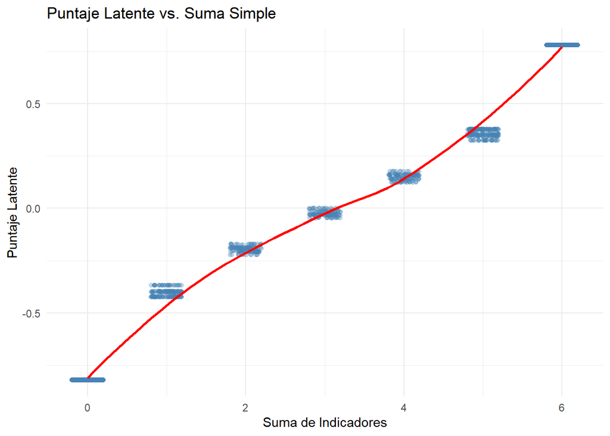

```r
puntajes <- lavPredict(ajuste, method = "regression")

datos <- items %>%
  mutate(suma_simple = rowSums(.),
         puntaje_latente = puntajes[,1])

ggplot(datos, aes(x = suma_simple, y = puntaje_latente)) +
  geom_jitter(width = 0.2, alpha = 0.3, color = "steelblue") +
  geom_smooth(method = "loess", se = FALSE, color = "red") +
  labs(title = "Puntaje Latente vs. Suma Simple",
       x = "Suma de Indicadores", y = "Puntaje Latente") +
  theme_minimal()
```

```r
cor(datos$suma_simple, datos$puntaje_latente)
```

```
## [1] 0.9929956
```

## 6. Confiabilidad: Coeficiente Omega

Además del alfa de Cronbach, una medida más robusta de confiabilidad en modelos de medición es el **coeficiente omega** (también llamado **omega total**). A diferencia de alfa, omega:

- **No asume que todos los ítems contribuyen igual** al constructo,
- **Toma en cuenta las cargas factoriales estimadas** en un modelo CFA,
- Es más adecuado cuando los ítems tienen **distintas precisiones**.

La función `compRelSEM()` del paquete `semTools` permite estimar el **omega total** directamente desde un modelo CFA:

Supongamos un modelo de un solo factor con:

- $\lambda_i$: carga factorial del ítem *i*,
- $\theta_i$: varianza del error del ítem *i*.

Entonces el **omega total** se calcula como:

$$\omega = \frac{\left(\sum_{i=1}^{k}
\lambda_i\right)^2}{\left(\sum_{i=1}^{k} \lambda_i\right)^2 +
\sum_{i=1}^{k} \theta_i}$$

Donde: - El numerador representa la **varianza explicada por el factor común**, - El denominador incluye tanto la varianza explicada como la **varianza de error**.

```r
compRelSEM(ajuste)
```

```
## factor
##  0.905
```

## Anexo: Simulación de indicadores con baja calidad de medición

```r
# Simulación de ítems poco relacionados con la latente (bajas cargas)
# Usamos pendientes pequeñas (e.g., 0.5) para lograr R2 bajos

beta_bajo <- rep(0.5, 3)
intercepts_bajo <- rep(0, 3)  # punto medio

# Calculamos probabilidades
logit_probs_bajo <- sapply(1:3, function(j) {
  inv_logit(beta_bajo[j] * eta + intercepts_bajo[j])
})

# Simulamos ítems binarios poco informativos
items_bajo <- as.data.frame(sapply(1:3, function(j) {
  rbinom(N, size = 1, prob = logit_probs_bajo[, j])
}))

colnames(items_bajo) <- paste0("item", 7:9)

# Unimos con la base de datos original
items <- bind_cols(items, items_bajo)
```

Esto nos permitirá analizar el impacto de **medición deficiente** sobre los puntajes, confiabilidad y ajuste del modelo.

## CFA con mezcla de buenos y malos indicadores

En esta sección ajustamos un modelo de medición con una combinación de tres buenos indicadores (`item1`, `item2`, `item3`) y tres malos (`item7`, `item8`, `item9`). Esto permite evaluar qué sucede cuando el instrumento contiene ítems poco informativos.

```r
# Modelo de 6 indicadores: 3 buenos (altos R2), 3 malos (bajos R2)
modelo_mixto <- '
  factor =~ item1 + item2 + item3 + item7 + item8 + item9
'

ajuste_mixto <- cfa(modelo_mixto, data = items, ordered = c("item1", "item2", "item3", "item7", "item8", "item9"),
                    estimator = "WLSMV")
```

### R² de los indicadores en el modelo mixto

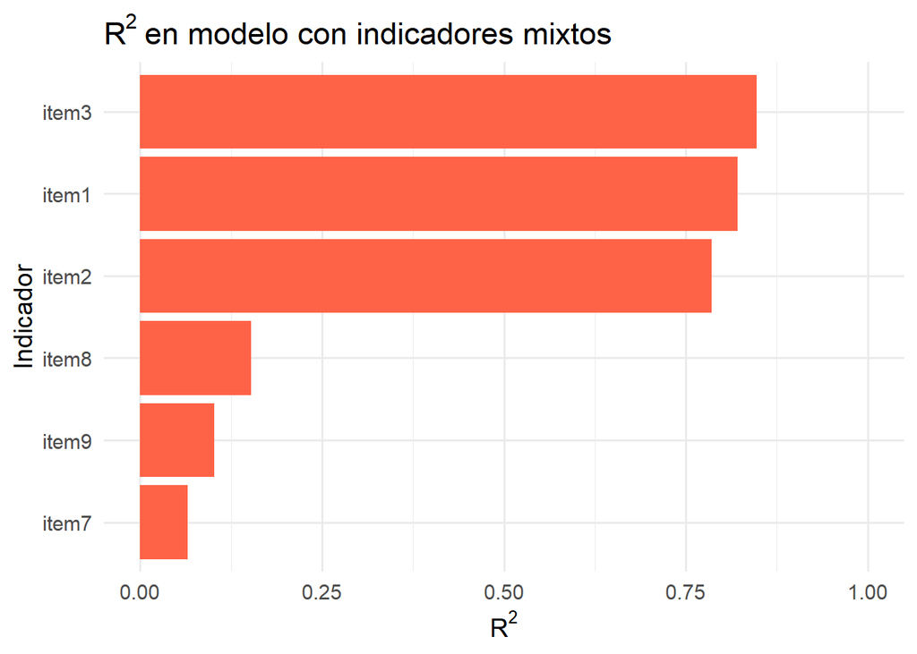

```r
r2_mixto <- inspect(ajuste_mixto, "r2")
r2_df_mixto <- data.frame(item = names(r2_mixto), R2 = as.numeric(r2_mixto))

ggplot(r2_df_mixto, aes(x = reorder(item, R2), y = R2)) +
  geom_col(fill = "tomato") +
  coord_flip() +
  ylim(0, 1) +
  labs(title = expression(R^2 ~ "en modelo con indicadores mixtos"),
       x = "Indicador", y = expression(R^2)) +
  theme_minimal(base_size = 14)
```

### Comparación entre puntaje latente y suma simple observada

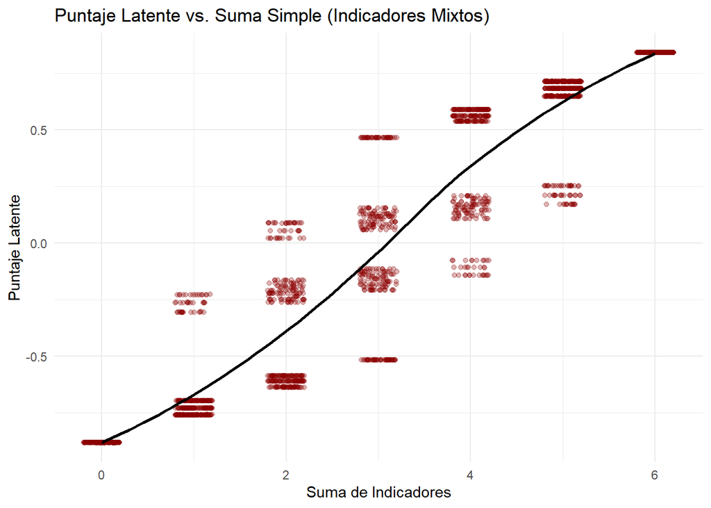

```r
# Puntajes latentes del modelo
puntajes_mixtos <- lavPredict(ajuste_mixto, method = "regression")

# Suma simple de los 6 ítems (3 buenos + 3 malos)
datos_mixtos <- items %>%
  mutate(suma_simple_mixta = rowSums(select(., item1, item2, item3, item7, item8, item9)),
         puntaje_latente_mixto = puntajes_mixtos[,1])

# Gráfica de comparación
ggplot(datos_mixtos, aes(x = suma_simple_mixta, y = puntaje_latente_mixto)) +
  geom_jitter(width = 0.2, alpha = 0.3, color = "darkred") +
  geom_smooth(method = "loess", se = FALSE, color = "black") +
  labs(title = "Puntaje Latente vs. Suma Simple (Indicadores Mixtos)",
       x = "Suma de Indicadores", y = "Puntaje Latente") +
  theme_minimal()
```

```r
# Correlación
cor(datos_mixtos$suma_simple_mixta, datos_mixtos$puntaje_latente_mixto)
```

```
## [1] 0.9363867
```

### Confiabilidad del modelo (Omega)

```r
compRelSEM(ajuste_mixto)
```

```
## factor
##  0.702
```

Esperamos que la **confiabilidad disminuya** y que la **correlación entre el puntaje simple y el latente se debilite**, comparado con el modelo original que usaba sólo buenos indicadores. Esto ilustra el efecto negativo de incluir ítems con bajo poder de medición.

## Modelo logit ordinal (ologit) con predictores latentes

```r
# Simulamos predictores altamente correlacionados con la variable latente
# eta ya existe de antes (variable latente base)
set.seed(456)
ingreso <- scale(eta + rnorm(length(eta), 0, 5.5))  # alta correlación con eta
educacion <- scale(eta + rnorm(length(eta), 0, .75))  # otro predictor latente

# Agregamos predictores al dataframe
datos_predictivos <- items %>%
  mutate(
    ingreso = ingreso,
    educacion = educacion,

    # Suma observada buena (ítems 1 a 6)
    score_bueno = rowSums(select(., item1:item6)),

    # Suma observada mixta (ítems 1-3 + 7-9)
    score_mixto = rowSums(select(., item1, item2, item3, item7, item8, item9))
  )
```

### Estimamos modelos logit ordinal

```r
library(MASS)  # para polr()
# score_bueno como variable dependiente ordinal
modelo_bueno <- polr(factor(score_bueno, ordered = TRUE) ~ ingreso + educacion,
                     data = datos_predictivos, Hess = TRUE)

summary(modelo_bueno)
```

```
## Call:
## polr(formula = factor(score_bueno, ordered = TRUE) ~ ingreso +
##     educacion, data = datos_predictivos, Hess = TRUE)
##
## Coefficients:
##            Value Std. Error t value
## ingreso   0.1244    0.04487   2.773
## educacion 2.1422    0.06930  30.910
##
## Intercepts:
##     Value    Std. Error t value
## 0|1  -1.6877   0.0685   -24.6426
## 1|2  -0.8734   0.0601   -14.5225
## 2|3  -0.3196   0.0572    -5.5912
## 3|4   0.1548   0.0567     2.7301
## 4|5   0.6921   0.0585    11.8313
## 5|6   1.5525   0.0662    23.4517
##
## Residual Deviance: 5561.188
## AIC: 5577.188
```

```r
# score_mixto como variable dependiente ordinal
modelo_mixto <- polr(factor(score_mixto, ordered = TRUE) ~ ingreso + educacion,
                     data = datos_predictivos, Hess = TRUE)

summary(modelo_mixto)
```

```
## Call:
## polr(formula = factor(score_mixto, ordered = TRUE) ~ ingreso +
##     educacion, data = datos_predictivos, Hess = TRUE)
##
## Coefficients:
##             Value Std. Error t value
## ingreso   0.08671    0.04055   2.138
## educacion 1.40759    0.04927  28.567
##
## Intercepts:
##     Value    Std. Error t value
## 0|1  -3.1059   0.0921   -33.7210
## 1|2  -1.5373   0.0616   -24.9385
## 2|3  -0.4911   0.0528    -9.2996
## 3|4   0.4126   0.0524     7.8758
## 4|5   1.3816   0.0595    23.2374
## 5|6   2.9272   0.0872    33.5540
##
## Residual Deviance: 6666.456
## AIC: 6682.456
```

### Interpretación esperada

Opcionalmente se pueden comparar pseudo-$R^2$, errores estándar, o visualizar predicciones.

## Comparación gráfica de coeficientes: score bueno vs score mixto

```r
# Extraemos coeficientes e intervalos de confianza para ambos modelos
coef_bueno <- summary(modelo_bueno)$coefficients
ci_bueno <- confint(modelo_bueno)
coef_mixto <- summary(modelo_mixto)$coefficients
ci_mixto <- confint(modelo_mixto)
```

```r
# Empaquetamos en data frames
coef_plot <- rbind(
  data.frame(modelo = "Score Bueno",
             predictor = rownames(coef_bueno),
             estimate = coef_bueno[, 1],
             lwr = ci_bueno[, 1],
             upr = ci_bueno[, 2]),
  data.frame(modelo = "Score Mixto",
             predictor = rownames(coef_mixto),
             estimate = coef_mixto[, 1],
             lwr = ci_mixto[, 1],
             upr = ci_mixto[, 2])
)

# Solo nos quedamos con los predictores (no interceptos)
coef_plot <- coef_plot %>%
  filter(predictor %in% c("ingreso", "educacion"))
```

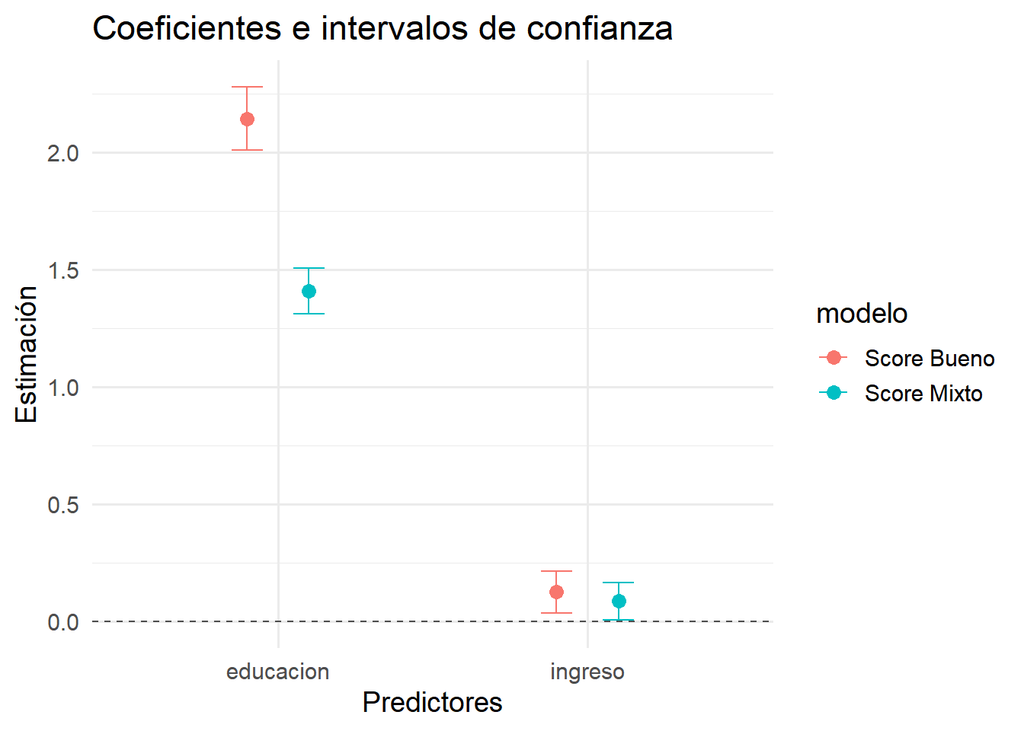

```r
# Gráfica de comparación
ggplot(coef_plot, aes(x = predictor, y = estimate, color = modelo)) +
  geom_point(position = position_dodge(width = 0.4), size = 3) +
  geom_errorbar(aes(ymin = lwr, ymax = upr), width = 0.2,
                position = position_dodge(width = 0.4)) +
  labs(title = "Coeficientes e intervalos de confianza",
       y = "Estimación", x = "Predictores") +
  geom_hline(yintercept = 0, linetype = "dashed", color = "gray30") +
  theme_minimal(base_size = 14)
```

## Comparación de clasificación: punto de corte de 1 privación

Identificamos como “pobres” a quienes tienen **una o más privaciones**. Comparamos la clasificación de pobreza entre el score bueno y el score mixto.

```r
# Crear variables binarias de pobreza
datos_predictivos <- datos_predictivos %>%
  mutate(
    pobre_bueno = ifelse(score_bueno >= 1, 1, 0),
    pobre_mixto = ifelse(score_mixto >= 1, 1, 0)
  )
```

### Tabla de contingencia

```r
table_clasificacion <- table(Pobre_Score_Bueno = datos_predictivos$pobre_bueno,
                             Pobre_Score_Mixto = datos_predictivos$pobre_mixto)

table_clasificacion
```

```
##                  Pobre_Score_Mixto
## Pobre_Score_Bueno    0    1
##                 0  147  403
##                 1   26 1424
```

### Medida de acuerdo

```r
library(caret)
confusionMatrix(factor(datos_predictivos$pobre_mixto),
                factor(datos_predictivos$pobre_bueno),
                positive = "1")
```

```
## Confusion Matrix and Statistics
##
##           Reference
## Prediction    0    1
##          0  147   26
##          1  403 1424
##
##                Accuracy : 0.7855
##                  95% CI : (0.7668, 0.8033)
##     No Information Rate : 0.725
##     P-Value [Acc > NIR] : 3.082e-10
##
##                   Kappa : 0.3167
##
##  Mcnemar's Test P-Value : < 2.2e-16
##
##             Sensitivity : 0.9821
##             Specificity : 0.2673
##          Pos Pred Value : 0.7794
##          Neg Pred Value : 0.8497
##              Prevalence : 0.7250
##          Detection Rate : 0.7120
##    Detection Prevalence : 0.9135
##       Balanced Accuracy : 0.6247
##
##        'Positive' Class : 1
##
```

Esto proporciona:

- **Exactitud global**,
- **Sensibilidad / especificidad** del score mixto respecto al score bueno,
- **Índice kappa** de acuerdo.

### Visualización de la discordancia

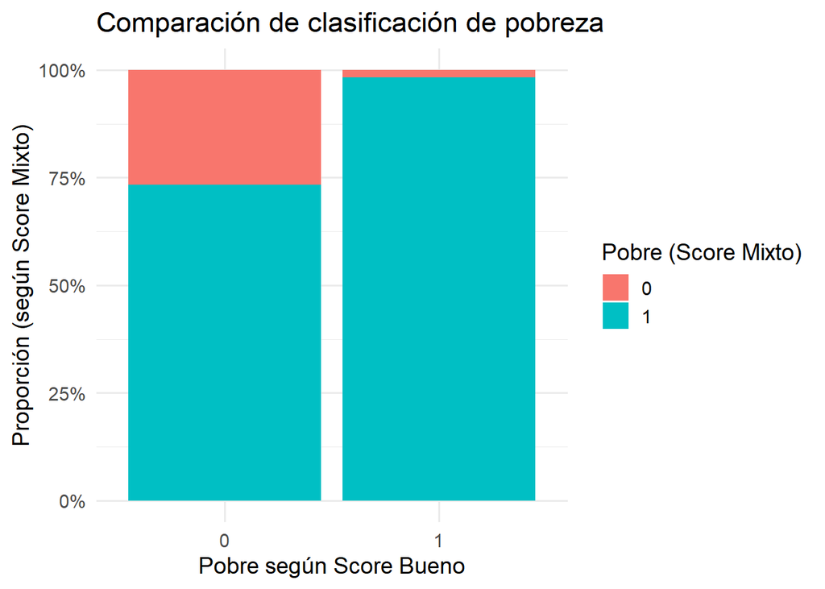

```r
ggplot(datos_predictivos, aes(x = factor(pobre_bueno), fill = factor(pobre_mixto))) +
  geom_bar(position = "fill") +
  labs(title = "Comparación de clasificación de pobreza",
       x = "Pobre según Score Bueno",
       y = "Proporción (según Score Mixto)",
       fill = "Pobre (Score Mixto)") +
  scale_y_continuous(labels = scales::percent) +
  theme_minimal(base_size = 14)
```

### Interpretación

- Las discrepancias muestran cómo la **mala medición genera errores de clasificación**.
- Un score con ítems mal diseñados puede **subestimar o sobreestimar** la pobreza.